# Writing Your Own Functions

March 16, 2017

## Code Reuse

- Copying and pasting code leads to errors
- Every time you use your code in a new spot, you might need to tweak some of it – you'll forget to tweak something important
- Every time you make your code better (update or fix a bug), you'll need to update it everywhere – you'll forget to update some spot

[figure not shown]

Don't be like this ape-guy…

## Functions solve these problems

- Changing function arguments is a lot more straightforward than searching and replacing to tweak code
- Updates / Fixes get applied every time the function is used

[figure not shown]

Learn from the MONOLITH!

## Creating your own function

Functions are objects (like almost everyting in R). You can create one with the `function()` function:

```r
outlier <- function(x) {
  x_median <- median(x, na.rm = TRUE)
  x_mad <- mad(x, na.rm = TRUE)
  out_log <- abs(x - x_median) / x_mad > 4
  out_index <- which(out_log)
  return(out_index)
}
```

## Simulate

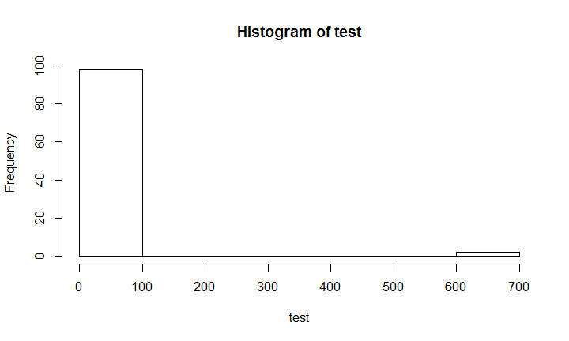

```r
test <- c(rpois(98, lambda = 25),
          rpois(2, lambda = 625))
hist(test)
```

## Test!

```r
outlier(test)
```

```
## [1]  99 100
```

```r
test[outlier(test)]
```

```
## [1] 631 610
```

[figure not shown]

Lookin' good.

## Arguments

Let's modify the function to control our outlier criterion:

```r
outlier <- function(x, crit = 4, na.rm = TRUE) {
  x_median <- median(x, na.rm = na.rm)
  x_mad <- mad(x, na.rm = na.rm)
  out_log <- abs(x - x_median) / x_mad > crit
  out_index <- which(out_log)
  return(out_index)
}
```

## Test!

```r
outlier(test)
```

```
## [1]  99 100
```

```r
test[outlier(test)]
```

```
## [1] 631 610
```

```r
outlier(test, crit = 3)
```

```
## [1]  26  57  99 100
```

```r
test[outlier(test, 3)]
```

```
## [1]  41  40 631 610
```

## Complex Returns

Sometimes you want to return more than one thing. Lists are vectors of things, so return a list!

```r
outlier <- function(x, crit = 4, na.rm = TRUE) {
  x_median <- median(x, na.rm = na.rm)
  x_mad <- mad(x, na.rm = na.rm)
  out_log <- abs(x - x_median) / x_mad > crit
  out_index <- which(out_log)
  return(list(value = x[out_index],
              index = out_index))
}
outlier(test)
```

```
## $value
## [1] 631 610
##
## $index
## [1]  99 100
```

## Really Complex Returns

```r
return(list(value = x[out_index],
            index = out_index,
            criteria = list(median = x_median,
                            mad_sd = x_mad)))
```

[figure not shown]

The list . . . it's full of lists!

## Add Some Argument Checks

```r
outlier <- function(x, crit = 4, na.rm = TRUE) {
  if (!is.numeric(x)) {
    stop("x must be numeric")
  }
  if (all(is.na(x))) {
    stop("x values are all NA")
  }
  if (!is.numeric(crit)) {
    stop("crit must be numeric")
  }
  if (length(crit) > 1) {
    crit <- crit[1]
    warning("length(crit) > 1, only the first element was used")
  }
  if (is.na(crit)) {
    warning("crit value is NA")
  } else if (crit < 0) {
    crit <- abs(crit)
    warning("crit < 0, abs(crit) used instead")
  }
  x_median <- median(x, na.rm = na.rm)
  x_mad <- mad(x, na.rm = na.rm)
  out_log <- abs(x - x_median) / x_mad > crit
  out_index <- which(out_log)
  return(list(value = x[out_index],
              index = out_index))
}
```

## Test!

```r
outlier(letters)
```

```
## Error in outlier(letters): x must be numeric
```

```r
outlier(test, c(4, 2))
```

```
## $value
## [1] 631 610
##
## $index
## [1]  99 100
```

## Test!

```r
outlier(rep(as.integer(NA), 50))
```

```
## Error in outlier(rep(as.integer(NA), 50)): x values are all NA
```

```r
outlier(test, -4)
```

```
## $value
## [1] 631 610
##
## $index
## [1]  99 100
```

## Test!

```r
outlier(test, TRUE)
```

```
## Error in outlier(test, TRUE): crit must be numeric
```

```r
outlier(test, as.integer(NA))
```

```
## $value
## integer(0)
##
## $index
## integer(0)
```

## Document!

roxygen2-style – ready for inclusion in a package!

```r
#' Get Robustly Identified Outliers
#'
#' @param x a numeric vector of data
#' @param crit a nonnegative numeric value
#' @param na.rm logical -- passed to median() and mad()
#'
#' @details Calculates the median of x and the robustly estimated
#' standard deviation of x, using the mad() function.  If the
#' absolute difference between the median and a value of x is
#' greater than crit robust standard deviations, then the value is
#' considered an outlier.
#'
#' @return a list with two elements: value is a numeric vector of
#' outliers, and index is an integer vector of outlier indices
#' @export

outlier <- function(x, crit = 4, na.rm = FALSE) {
  if (!is.numeric(x)) {
    stop("x must be numeric")
  }
  if (all(is.na(x))) {
    stop("x values are all NA")
  }
  if (!is.numeric(crit)) {
    stop("crit must be numeric")
  }
  if (length(crit) > 1) {
    crit <- crit[1]
    warning("length(crit) > 1, only the first element was used")
  }
  if (is.na(crit)) {
    warning("crit value is NA")
  } else if (crit < 0) {
    crit <- abs(crit)
    warning("crit < 0, abs(crit) used instead")
  }
  x_median <- median(x, na.rm = na.rm)
  x_mad <- mad(x, na.rm = na.rm)
  out_log <- abs(x - x_median) / x_mad > crit
  out_index <- which(out_log)
  return(list(value = x[out_index],
              index = out_index))
}
```

## Default Returns

If you don't use the return() function, your function will return the result of the last statement.

```r
add_five <- function(x) {
  x + 5
}
add_five(pi)
```

```
## [1] 8.141593
```

## Invisible Returns

Use the `invisible()` function, obviously:

```r
add_five <- function(x) {
  invisible(x + 5)
}
add_five(pi)
z <- add_five(sqrt(2))
z
```

```
## [1] 6.414214
```

## Ellipses

You can use ellipses to pass unspecified arguments to functions within your function:

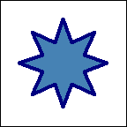

```r
star <- function(x, y, points, radius, ...) {
  old_par <- par(mar = c(0, 0, 0, 0))
  on.exit(par(old_par))
  symbols(x = x, y = y,
          stars = matrix(rep(radius * c(1, 0.5), points), nrow = 1),
          inches = FALSE, ...)
}
star(0, 0, 8, 0.75, bg = "steelblue", lwd = 4, fg = "navy")
```

## Dropping the Braces

If your function code is really short, you **can** skip the braces, and it will still work:

```r
add_pi <- function(x) x + pi
add_pi(cos(pi/2))
```

```
## [1] 3.141593
```

## Ephemeral Functions

Sometimes you don't write a function to last, and a sloppy function is good enough.

```r
sapply(mtcars, FUN = function(x) median(abs(x - median(x))))
```

```
##     mpg     cyl    disp      hp    drat      wt    qsec      vs      am
##  3.6500  2.0000 94.7500 52.0000  0.4750  0.5175  0.9550  0.0000  0.0000
##    gear    carb
##  1.0000  1.0000
```

## Watch out!

If you don't pay attention, your function will do things that you don't want. Try to keep your functions **narrowly focused**:

- It is easier to write a small function that does one simple thing than a big function that does something complex
- So, if you have a complex task, write a bunch of simple functions first, then put them together (perhaps in a bigger function)

[figure not shown]

Watch out for the unexpected!

## Environments

R objects are organized into environments. Usually your code runs in the global environment. Your function *can* reference objects in the global environment . . .

```r
z <- 5
double_z <- function() {
  return(z * 2)
}
double_z()
```

```
## [1] 10
```

but it is usually better to pass objects as arguments.

## Function Environments

But, your function code is evaluated in its own environment – so objects that you create or modify generally have no effect on objects in the global environment:

```r
z <- 5
double_z <- function() {
  z <- z * 2
  return(z)
}
double_z()
```

```
## [1] 10
```

```r
z
```

```
## [1] 5
```

## Black Magic

Modifying or creating objects outside the function environment is **black magic**, and should be avoided…

[figure not shown]

because it's real.

## The Obvious Alternative

Assign the function result to an object in the global environment

```r
z <- 5
double_it <- function(x) {
  return(x * 2)
}
z <- double_it(z)
z
```

```
## [1] 10
```

## Any Questions?

[figure not shown]

https://github.com/NickSalkowski/Writing_Functions_20170316